# Praca domowa nr 2

Piotr Olesiejuk

# Funkcje NSE

```r
#install.packages("microbenchmark")
#install.packages("ggplot2")
#install.packages("ggthemes")
library(ggplot2)
library(microbenchmark)
library(ggthemes)
library(patchwork)
```

```r
zadanieDomowe1 <- function(fun) {
  myFun <- function(input_list, x, ...) {
    fun(eval(substitute(x), input_list), ...)
  }
  myFun
}
zadanieDomowe2 <- function(fun) {
  myFun <- function(input_list, x, ...) {
    do.call(fun, list(eval(substitute(x), input_list), ...))
  }
  myFun
}
zadanieDomowe3 <- function(fun) {
  myFun <- function(input_list, x , ...) {
    nse_element <- substitute(x)
    with(input_list, do.call(fun, list(nse_element, ...)))
  }
  myFun
}
```

## Metodyka testowania wydajności

Do przetestowania wydajności wykorzystano cztery funkcje: min, mean, unlist (z parametrami use.names = TRUE oraz use.names = FALSE) oraz lm. Każda z tych funkcji została przetestowana na małym oraz dużym zestawie danych. Dane do testowania były w każdym przypadku następujące

```r
generate_big_list <- function(list_size = 100, element_size = 1000) {
  l <- list()
  for (i in 1:list_size) {
    l[[paste0("var", i)]] = sample(1:element_size, size = element_size, replace = FALSE)
  }
  l
}
small_data <- list(var21 = c(10,3,6,7), var32 = c(4,2,1,5))
big_data <- generate_big_list()
```

Lista big_data została wygenerowana raz i posłużyła do testów wszystkich funkcji.

Funkcje były testowane z wykorzystaniem pakietu microbenchmark poprzez funkcję testing. W przypadku funkcji lm, w funkcji testującej został zmieniony argument przekazywany do odpowiednich funkcji w NSE z var1 na var1~var2. Były prowadzone próby przekazywania wyrażenia jako argumentu w funkcji testing, jednak nie udało się wykonać takiej operacji stąd taka decyzja w kwestii testowanie. Problemem, była nazwa zmiennej przekazywanej do funkcji w NSE.

```r
testing <- function(func, data, argmts = list(), areArgs = FALSE, title = "Time performance") {


  fun_NSE_1 <- zadanieDomowe1(func)
  fun_NSE_2 <- zadanieDomowe2(func)
  fun_NSE_3 <- zadanieDomowe3(func)
  #browser()
  t <- numeric(length = 3)
  if (areArgs == FALSE){
    t[1] <- mean(microbenchmark(fun_NSE_1(data, var21), times = 1000)$time)
    t[2] <- mean(microbenchmark(fun_NSE_2(data, var21), times = 1000)$time)
    t[3] <- mean(microbenchmark(fun_NSE_3(data, var21), times = 1000)$time)
  }
  else{
    t[1] <- mean(microbenchmark(fun_NSE_1(data, var21, argmts), times = 1000)$time)
    t[2] <- mean(microbenchmark(fun_NSE_2(data, var21, argmts), times = 1000)$time)
    t[3] <- mean(microbenchmark(fun_NSE_3(data, var21, argmts), times = 1000)$time)
  }
  fun_names <- c("1", "2", "3")

  t <- sapply(t, function(x) { x / 1000})

  ggplot(data = data.frame(time = t, solution = fun_names),
         aes(x = solution, y = time, fill = fun_names)) +
    geom_bar(stat = 'identity') +
    ylim(0, 30) +
    ggtitle(paste(title, ' [microsec.]')) +
    theme_fivethirtyeight() +
    theme(plot.title = element_text(hjust = 0.5), legend.position = 'none',
          panel.background = element_blank(),
          plot.background = element_blank())
}
```

# Wyniki

## Min

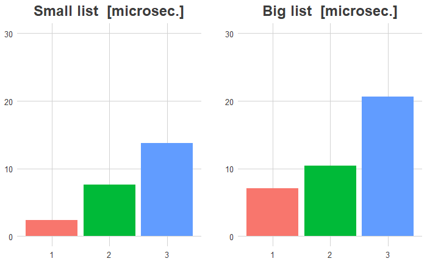

## Mean

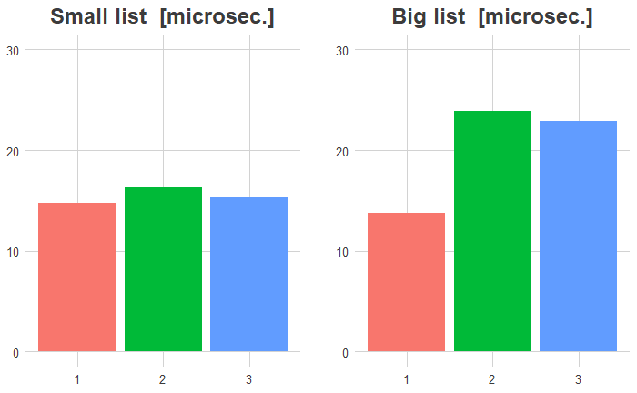

## Unlist (use.names = FALSE)

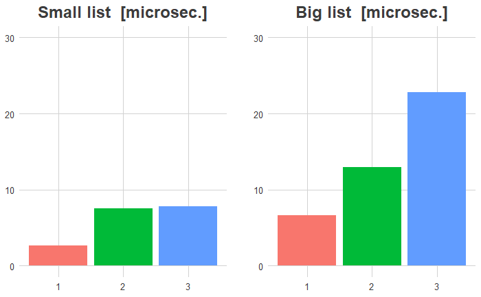

## Unlist (use.names = TRUE)

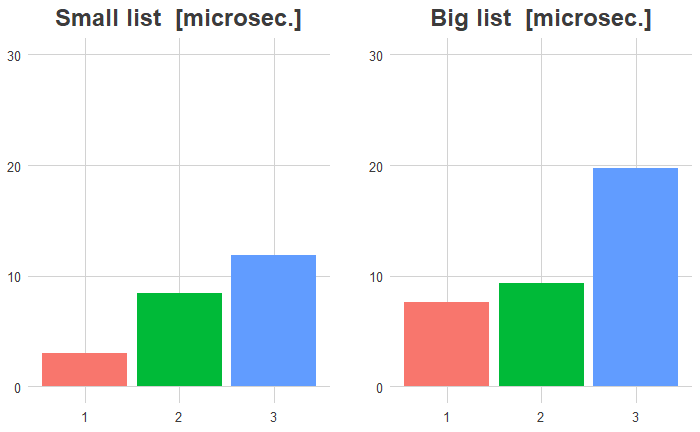

## lm

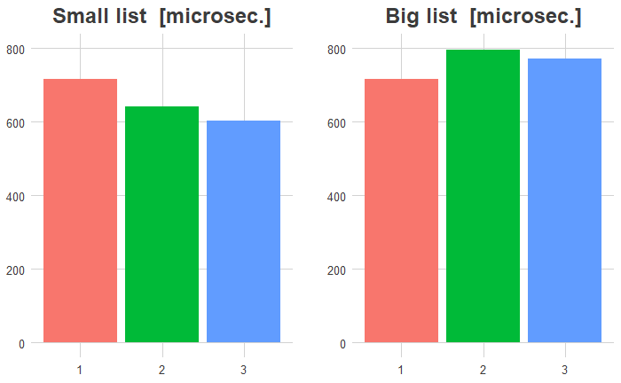

# Wnioski

Jak widać najlepiej spisuje się rozwiązanie nr 1, rozwiązanie 2 często jest drugim wynikiem bądź blisko wyniku rozwiązania nr 3. Rozwiązanie numer 3 spisuje się najczęściej najgorzej, ciekawe jest, że w przypadku budowania modelu liniowego dla małej listy poradził sobie najlepiej. Porównując wydajność na dużych i małych rozmiarach danych można dojść do wniosku, że wyniki nie różnią się znacząco. Rezultaty są lepsze dla mniejszych danych, zaś różnica zależy od wykorzystanej metody.